# Part II - Factors affecting BorrowersAPR and Loan Amount

# (Exploring Loan Data from Prosper)

## by Ibiyinka Daramola

## Investigation Overview

In these investigation, I want to look at the most important factors that influence BorrowersAPR and Loan Amount. The main focus wil be on the Income Range and the ProsperScore

## Dataset Overview

This data set contains 113,937 loans with 81 variables on each loan from a loan company called Prosper. The variables include loan amount, borrower rate (or interest rate), current loan status, borrower income, and many others.Only 15 variables were retained as the ones of interest

# Distribution of BorrowerAPR

The BorrowerAPR has a small range of values (about 0.01-0.43) with a lot of data points. An histogram plot shows a roughly normal distribution with some high outliers close to 0 and around 0.35-0.37 APR values

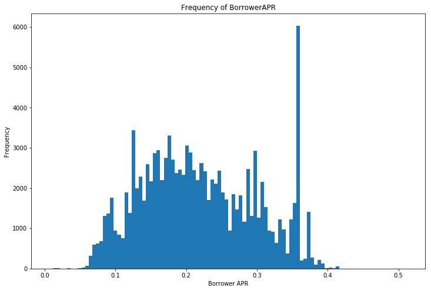

# Distribution of LoanOriginalAmount

An histogram of this showed a skewness of the data to the right. It also revealed notable peaks at certain intervals suggestive that standard loan amounts are ususally given which are sometimes varied.

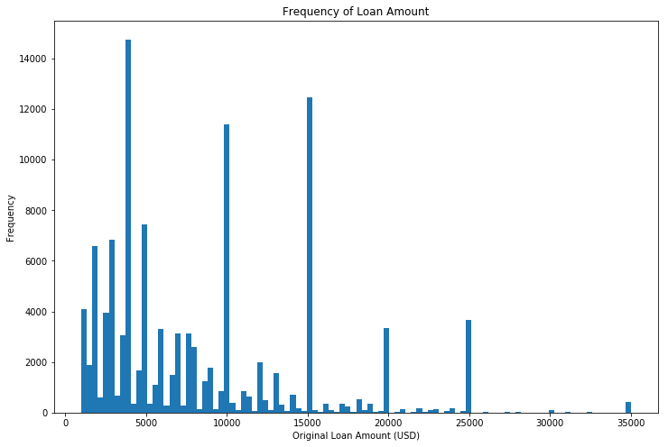

# BorrowerAPR vs LoanOriginalAmount

Plotting BorrowerAPR vs LoanOriginalAmount reveals an aproximate inverse relationship. There is a notable concentration of data points below a certain loanamount(\$15,000) and at certain intervals(of about \\$5000)

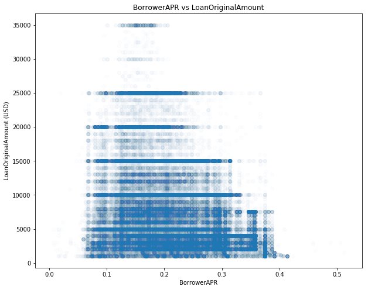

# Categorical Variables vs BorrowerAPR

Amongst other information, the violin plots reveal:

- More homeowners had lower BorrowerAPR
- Higher income ranges had lower BorrowerAPRs
- BorrowerAPR fell with increasing ProsperScores

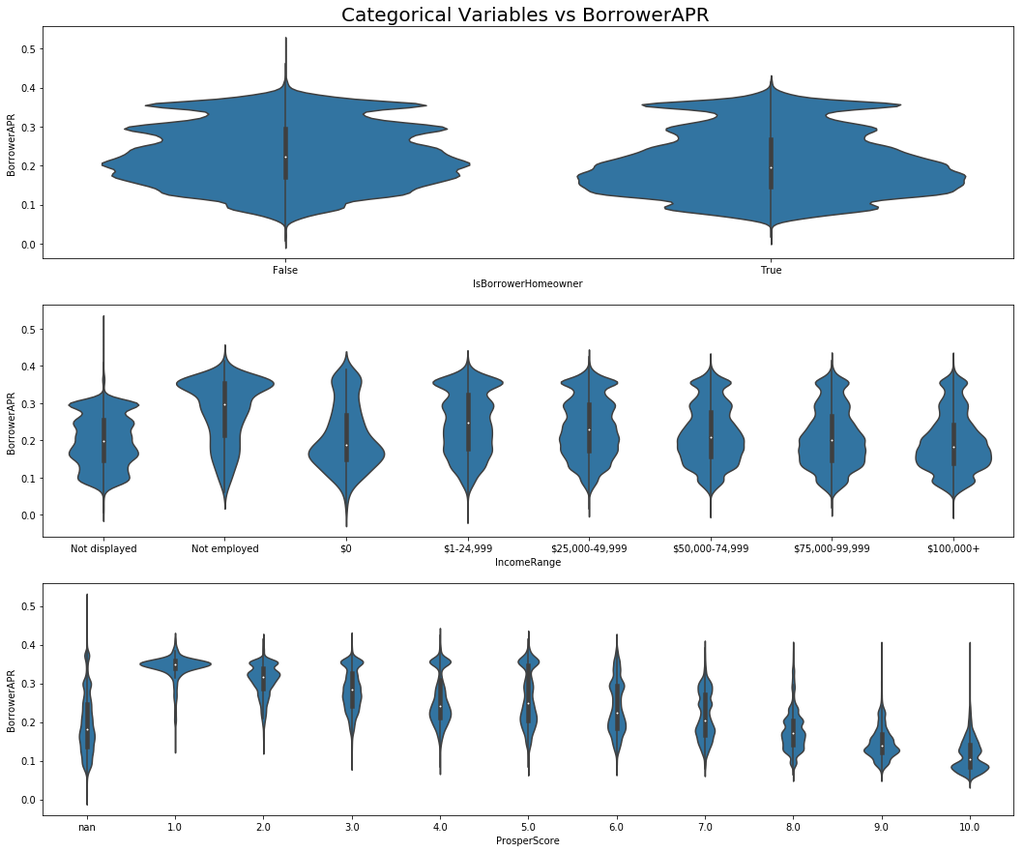

# Categorical Variables vs OriginalLoanAmount

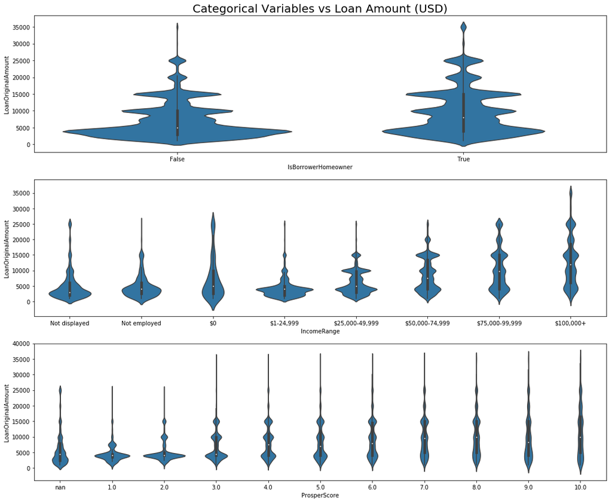

# BorrowerAPR vs LoanOriginalAmount vs ProsperScore

A scatter plot with a color bar is used to make this multivariate plot

The plot shows that BorrowerAPR increases with falling ProsperScore and Loan Amount

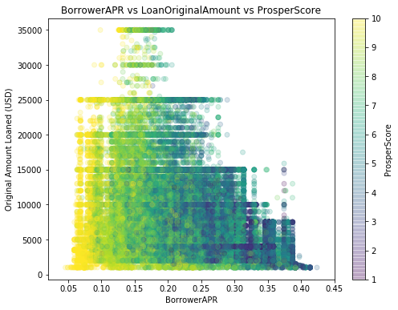

# Summary

- BorrowerAPR falls with increasing incomerange and prosper score
- LoanOriginalAmount increases with increasing incomerange and Prosperscore